# Effects of Time on Loan Characteristics

## by Rasha Hosny

## Investigation Overview

> I want to investigate some data related to the borrowers such as income to dept ratio and what they can afford on monthly baseis. Also I want to investigate some data related to the loan it self such as Loan Origination Quarter, loan status, APR.

## Dataset Overview

> The data consists of 81 record for each loan, some of these data has null values and some has non-valuable data. These data is ranged between 2005 and 2014 with various characteristics of those loans. Out of these data there are 61 numeric variables and 20 objectis variables. I will work on 18 variables out of 81 and they are consisting of 5 discrete variables and 13 continuous variables.

## Loan Origination Quarter

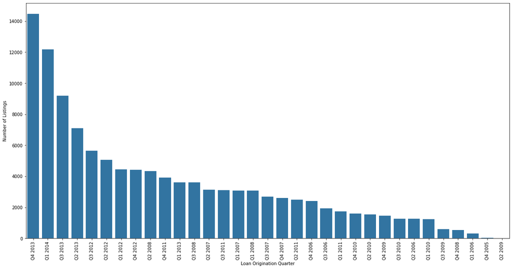

## Fluctuation of loan orgination with years

> I have found during my investiagtion that origination loans trend start to increase from the first quarter of 2006 then faill in the last quarter of 2008 till Q3 2009, I think this is where the world econonmy has been failld. I have found this on the balance web site ("The 2008 financial crisis was the worst economic disaster since the Great Depression of 1929. It occurred despite the efforts of the Federal Reserve and the U.S. Department of the Treasury. The crisis led to the Great Recession, where housing prices dropped more than the price plunge during the Great Depression. Two years after the recession ended, unemployment was still above 9%. That doesn't count those discouraged workers who had given up looking for a job.") It has been noticed also that after 2009 the loan origination begain to increase with little fluctuation till the end of the series.

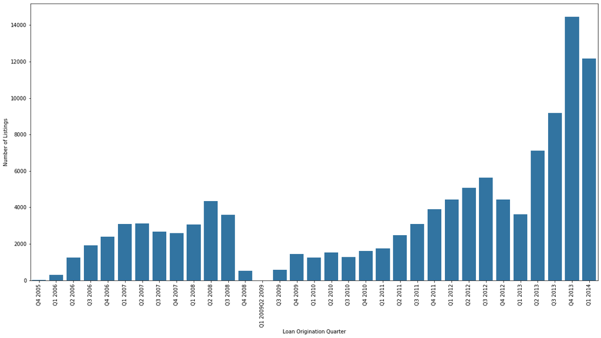

## Correlation between Loan characteristics

> I study the correlation between loan chractristics using heatmap. A heatmap is a two-dimensional graphical representation of data where the individual values that are contained in a matrix are represented as colors.

> There are positive strong relation between borrowerAPR and borrowerRate and between upper and lower credit score; in which it's logic as APR depend on Rate. But for other pairs, there are no strong positive relationships. -ve sign for borrower rate and APR with credit score is logic also as higher credit score means the borrowers are more trusted, therefore it recevied lower APR.

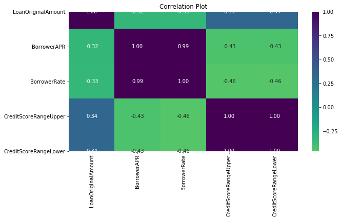

## The effect of time on income range and Loan categories

> It has been noticed here that starting from year 2008 the borrowers beagins their loans and that Dept consolidation is the king amoung all of those loans. Also the loans has a large increase starting from last quarntile for 2013.

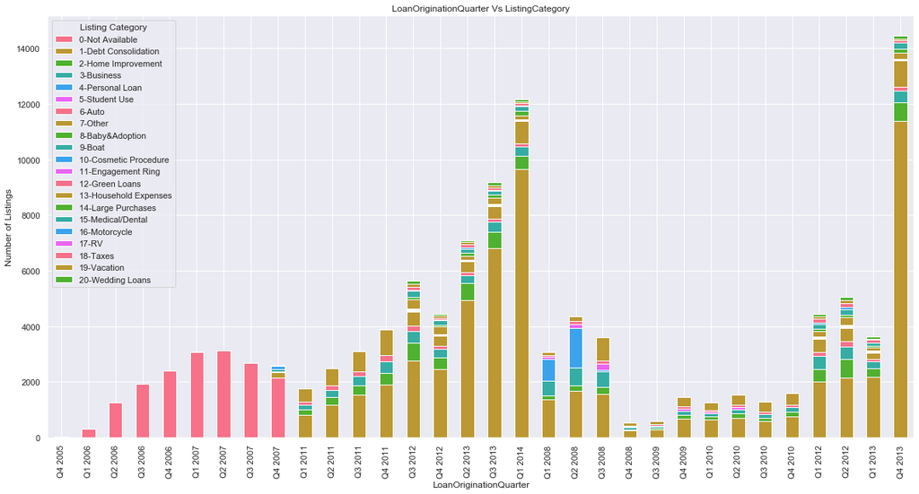

> Finally I study the relation between Income Range and Loan Origination Quarter. Here the I found why loans starts to increase from 2013, this is because the income range has noticable increase in this period. The sallary ranges of 75-99 and +100 thousand dollar increase starting from 2013.

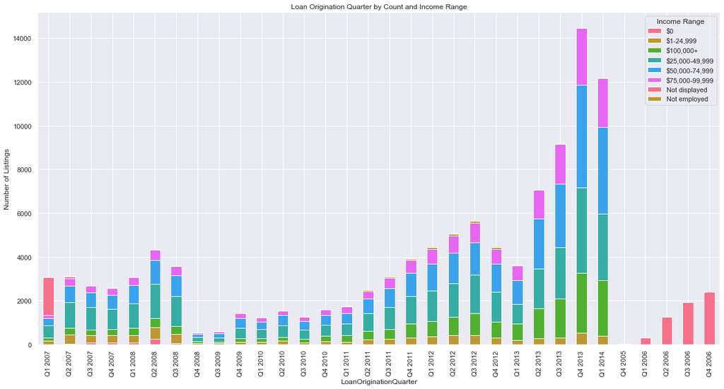

```
[NbConvertApp] Converting notebook ProsperLoan_slide_deck.ipynb to slides
[NbConvertApp] Writing 506954 bytes to ProsperLoan_slide_deck.slides.html
```